# Tarea4_AlejandroBarrantes

Alejandro Barrantes Castro

2023-04-14

```r
setwd("~/ALEJANDRO/1er Ciclo 2023/Mineria de Datos/Tarea 4/DatosTarea")
Datos <- read.csv('EjemploAlgoritmosRecomendacion.csv', header=TRUE, sep=';',dec=',',row.names=1)
```

### a.1) Ejecute un Clustering Jerarquico con la distancia euclıdea y la agregacion del Salto Maximo, Salto Mınimo, Promedio y Ward. Guarde la tabla de datos en el archivo AlgoritmosRecomendacion2.csv con el cluster al que pertenece cada individuo para el caso de la agregacion de Ward usando 2 clusteres.

### a.2) Salto Maximo

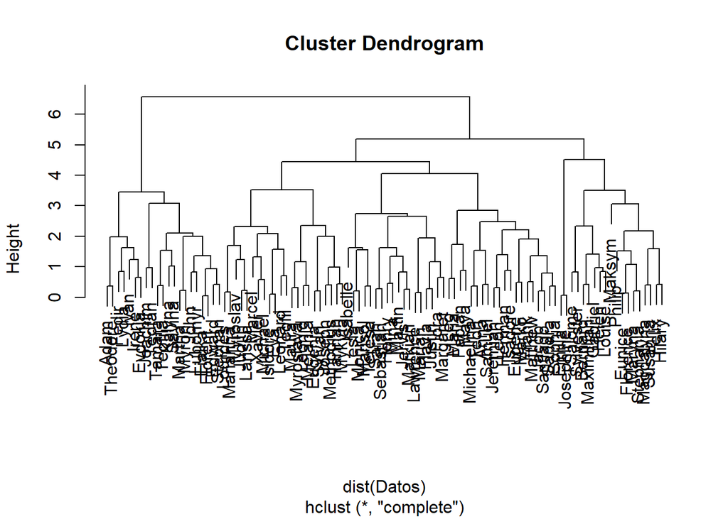

```r
modelo <- hclust(dist(Datos),method = "complete")
plot(modelo)
```

### a.3) Salto Mınimo

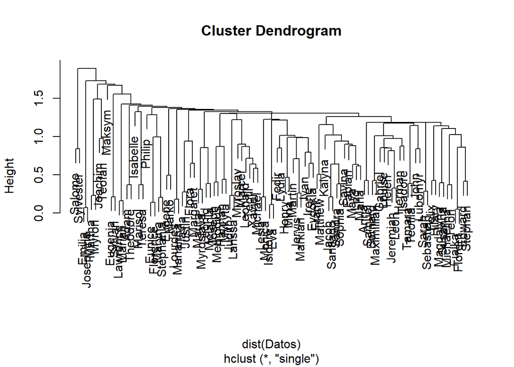

```r
modelo <- hclust(dist(Datos),method = "single")
plot(modelo)
```

### a.4) Promedio

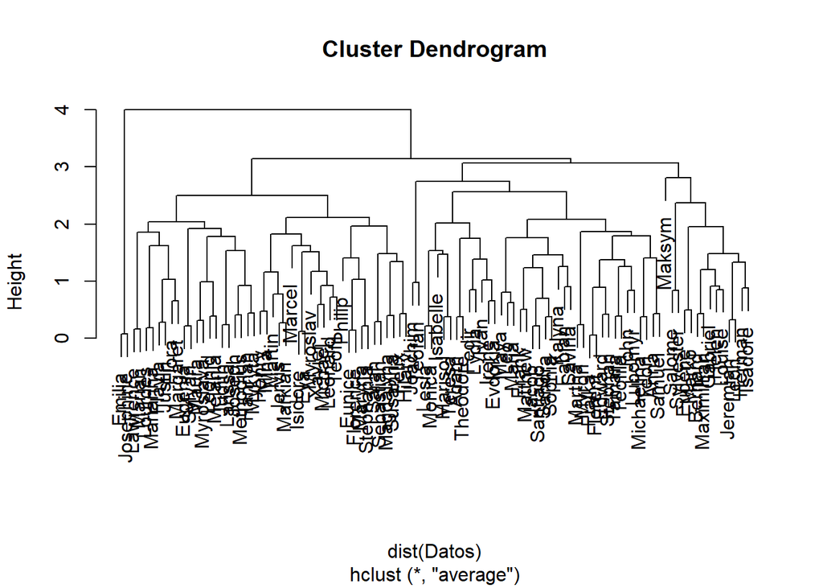

```r
modelo <- hclust(dist(Datos),method = "average")
plot(modelo)
```

### a.5) Ward

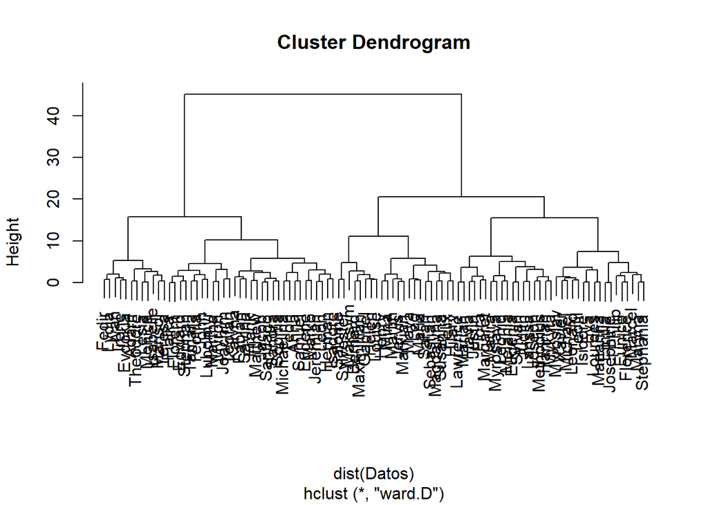

```r
modelo <- hclust(dist(Datos),method= "ward.D")
plot(modelo)
```

### a.6) Guarde la tabla de datos en el archivo AlgoritmosRecomendacion2.csv con el cluster al que pertenece cada individuo para el caso de la agregacion de Ward usando 2 clusteres

```r
Grupo<-cutree(modelo,k=2)
NDatos<-cbind(Datos,Grupo)
write.csv(NDatos,"EjemploAlgoritmosRecomendacion2.csv")
```

## b) “Corte” el arbol anterior usando 2 clusteres y la agregacion de Ward, interprete los resultados usando interpretacion usando graficos de barras (Horizontal-Vertical) y usando graficos tipo Radar.

### 1.b) “Corte” el arbol anterior usando 2 clusteres y la agregacion de Ward, interprete los resultados usando interpretacion usando graficos de barras (Horizontal-Vertical) y usando graficos tipo Radar

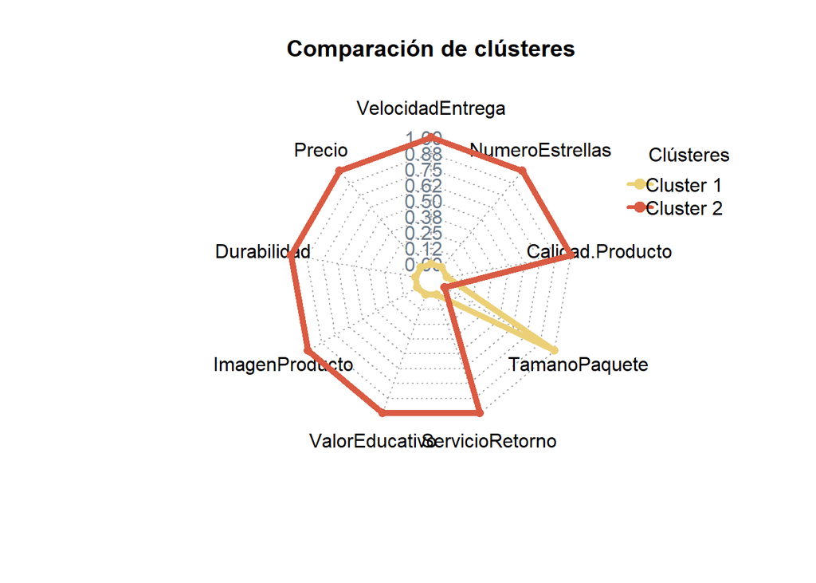

```r
modelo <- hclust(dist(Datos),method= "ward.D")
grupos <- cutree(modelo, k=2)
NDatos<-cbind(Datos,grupos)

centro.cluster1<-centroide(1,(Datos),(grupos))
centro.cluster2<-centroide(2,(Datos),(grupos))
centros<-rbind(centro.cluster1,centro.cluster2)

maximos<-apply(centros,2,max)
minimos<-apply(centros,2,min)
centros<-rbind(minimos,centros)
centros<-rbind(maximos,centros)

color <- c("#ECD078","#D95B43","#C02942","#542437","#53777A")


radarchart(as.data.frame(centros),maxmin=TRUE,axistype=4,axislabcol="slategray4",
           centerzero=FALSE,seg=8, cglcol="gray67",
           pcol=color,plty=1,plwd=5,title="Comparación de clústeres")

legenda <-legend(1.5,1, legend=c("Cluster 1","Cluster 2"),
                 seg.len=-1.4,title="Clústeres",pch=21,bty="n" ,lwd=3, y.intersp=1,
                 horiz=FALSE,col=color)
```

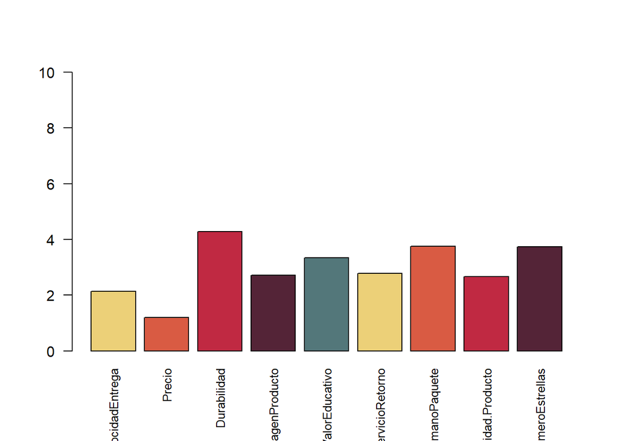

```r
barplot(centros[1,],col=color,las=2, cex.names = 0.8, ylim = c(0,10))
```

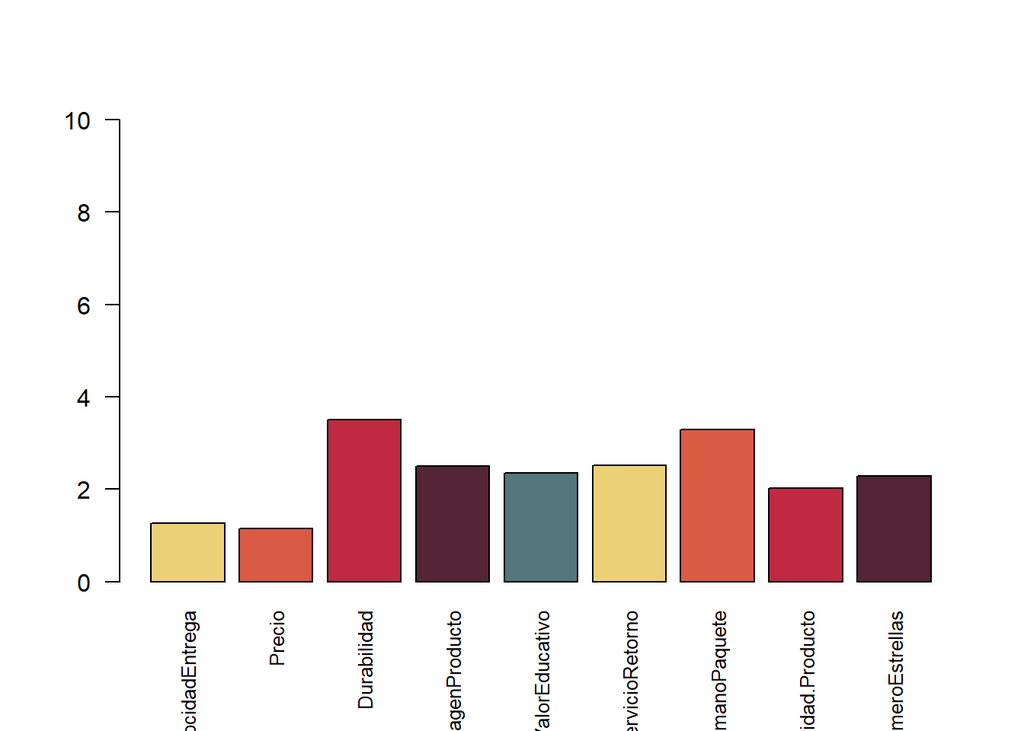

```r
barplot(centros[2,],col=color,las=2, cex.names = 0.8, ylim = c(0,10))
```

## 1.c) Si se tienen 4 clusteres usando agregacion de Ward ¿Que productos recomendarıa a Teresa, a Leo y a Justin?, es decir, ¿los productos que compra cual otro cliente? Usando distancia euclıdea ¿cual es la mejor recomendacion de compra que le podemos hacer a Teresa, a Leo y a Justin?

```r
modelo <- hclust(dist(Datos),method= "ward.D")
grupos <- cutree(modelo, k=4)
NDatos<-cbind(Datos,grupos)

grupo.teresa<-NDatos["Teresa",]$grupos
grupo.leo<-NDatos["Leo",]$grupos
grupo.justin<-NDatos["Justin",]$grupos
```

#### Recomendaciones para Teresa: Comprar los productos que compran

```r
row.names(NDatos[NDatos$grupos==grupo.teresa,])
```

```
##  [1] "Adam"     "Marisol"  "Irene"    "Isabelle" "Evdokia"  "Fedir"
##  [7] "Ivan"     "Lesia"    "Lydia"    "Monica"   "Theodore" "Teresa"
```

#### Recomendaciones para Leo: Comprar los productos que compran

```r
row.names(NDatos[NDatos$grupos==grupo.leo,])
```

```
##  [1] "Bernard"     "Gabriel"     "Henry"       "Felix"       "Helen"
##  [6] "Hilary"      "Jervis"      "Leo"         "Louise"      "Magdalyna"
## [11] "Maksym"      "Maria"       "Markian"     "Martin"      "Maya"
## [16] "Maximillian" "Mina"        "Salome"      "Sarah"       "Sebastian"
## [21] "Susanna"     "Sylvester"
```

#### Recomendaciones para Justin: Comprar los productos que compran

```r
row.names(NDatos[NDatos$grupos==grupo.justin,])
```

```
##  [1] "Emilia"    "Philip"    "Xavier"    "Isidore"   "Joseph"    "Eugenia"
##  [7] "Eunice"    "Eva"       "Flavia"    "Flora"     "Florence"  "Hannah"
## [13] "Lourdes"   "Josephine" "Judith"    "Justin"    "Larissa"   "Lawrence"
## [19] "Leonard"   "Leonid"    "Marcel"    "Margaret"  "Marian"    "Marianna"
## [25] "Maryna"    "Maura"     "Melania"   "Methodius" "Michael"   "Mykyta"
## [31] "Myroslav"  "Myroslava" "Stephania" "Sylvan"    "Teofil"
```

## 1.d) Construya un clustering jerarquico sobre las componentes principales del ACP.

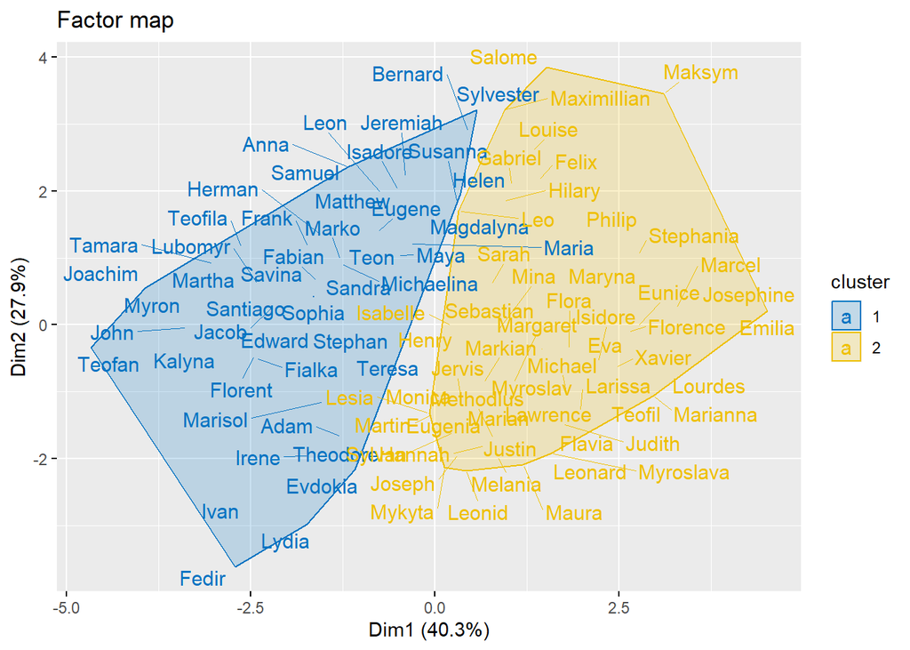

```r
setwd("~/ALEJANDRO/1er Ciclo 2023/Mineria de Datos/Tarea 4/DatosTarea")
Datos <- read.csv('EjemploAlgoritmosRecomendacion.csv', header=TRUE, sep=';',dec=',',row.names=1)
res  <- PCA(Datos , scale.unit=TRUE, ncp=5, graph = FALSE)
res.hcpc <- HCPC(res, nb.clust = -1, consol = TRUE, min = 2, max = 2, graph = FALSE)

fviz_cluster(res.hcpc,repel = TRUE,show.clust.cent = TRUE,palette = "jco",main = "Factor map",geom = "text", select.ind = list(cos2 = 0.1))
```

# EJERCICIO 2

```r
setwd("~/ALEJANDRO/1er Ciclo 2023/Mineria de Datos/Tarea 4/DatosTarea")
Datos <- read.csv("VotosCongresoUS.csv",header=TRUE, sep=",", dec=".")
Datos<-as.data.frame(lapply((Datos), factor))
```

## a) Ejecute una clasificacion jerarquica sobre esta tabla de datos usando la funcion daisy ya que los datos son cualitativos. Use metrica euclidean y metodo complete (deje el resultado en la variable jer). Cargue los datos con la siguiente instruccion:

```r
D<-daisy((Datos), metric = "euclidean")
jer<-hclust(D, method = "complete")
```

## b) Luego “corte” el arbol usando 3 clusteres y ejecute el siguiente codigo

```r
grupo<-cutree(jer, k = 3)
NDatos<-cbind((Datos),grupo)

cluster<-NDatos$grupo
sel.cluster1<-match(cluster,c(1),0)
Datos.Cluster1<-NDatos[sel.cluster1>0,]
dim(Datos.Cluster1)
```

```
## [1] 232  18
```

```r
sel.cluster2<-match(cluster,c(2),0)
Datos.Cluster2<-NDatos[sel.cluster2>0,]
dim(Datos.Cluster2)
```

```
## [1] 198  18
```

```r
sel.cluster3<-match(cluster,c(3),0)
Datos.Cluster3<-NDatos[sel.cluster3>0,]
dim(Datos.Cluster3)
```

```
## [1]  5 18
```

### Explique que hace el codigo anterior. Luego ejecute el siguiente codigo:

#### grupo<-cutree(jer, k = 3): Se realiza un análisis de cluster utilizando la función cutree() con un objeto de clustering previamente generado (jer) y se especifica k=3 para indicar que se desea dividir los datos en tres grupos.

#### NDatos<-cbind(Datos,grupo): Se crea un nuevo objeto llamado NDatos que es una combinación de los datos originales (Datos) y la variable de cluster generada en el paso anterior (grupo). La función cbind() combina las dos matrices por columnas.

#### cluster<-NDatos$grupo: Se crea un objeto llamado cluster que contiene únicamente la variable de cluster (grupo) de NDatos.

#### sel.cluster1<-match(cluster,c(1),0): Se crea un objeto llamado sel.cluster1 que selecciona todas las filas de NDatos que pertenecen al cluster 1. La función match() devuelve una correspondencia de los elementos de cluster con el valor 1, y el valor 0 para aquellos que no lo son.

#### Datos.Cluster1<-NDatos[sel.cluster1>0,]: Se crea un nuevo objeto de datos llamado Datos.Cluster1 que contiene únicamente las filas de NDatos que pertenecen al cluster 1. La selección se realiza mediante un subíndice que toma las filas donde sel.cluster1 es mayor que cero (es decir, las que pertenecen al cluster 1).

#### dim(Datos.Cluster1): La función dim() devuelve las dimensiones (número de filas y columnas) de Datos.Cluster1. Este comando se repite para los otros dos grupos (Datos.Cluster2 y Datos.Cluster3).

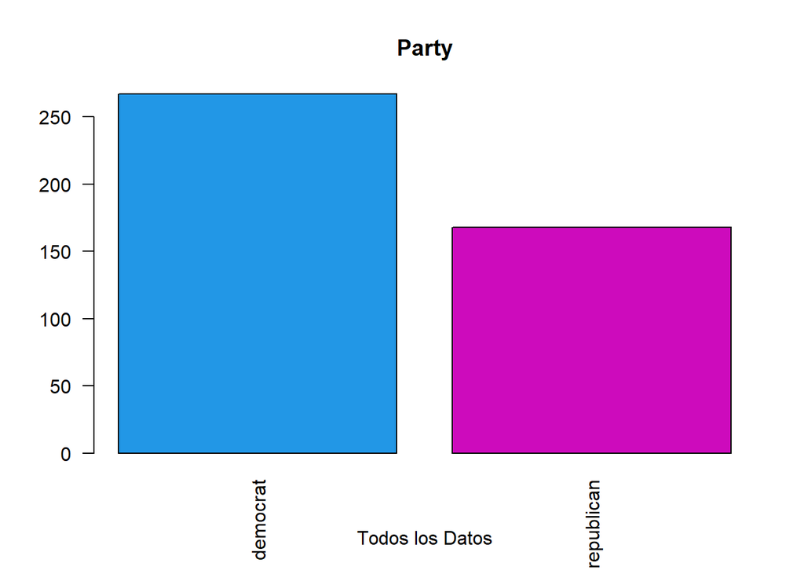

```r
plot(Datos$Party,col=c(4,6),las=2,main="Party",xlab="Todos los Datos")
```

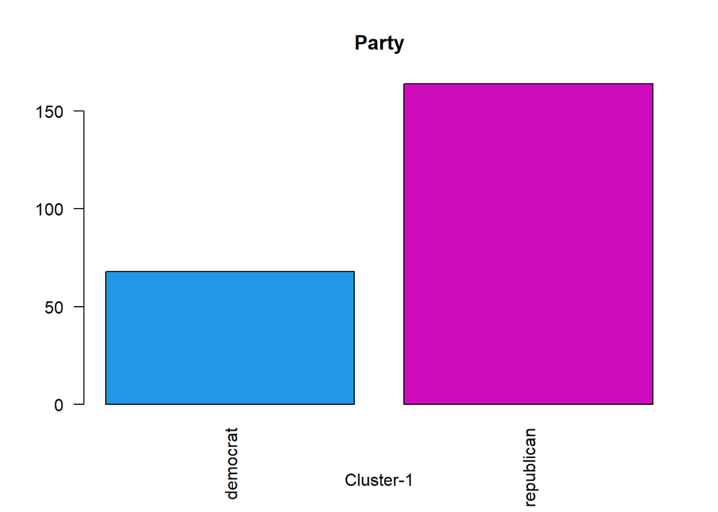

```r
plot(Datos.Cluster1$Party,col=c(4,6),las=2,main="Party",xlab="Cluster-1")
```

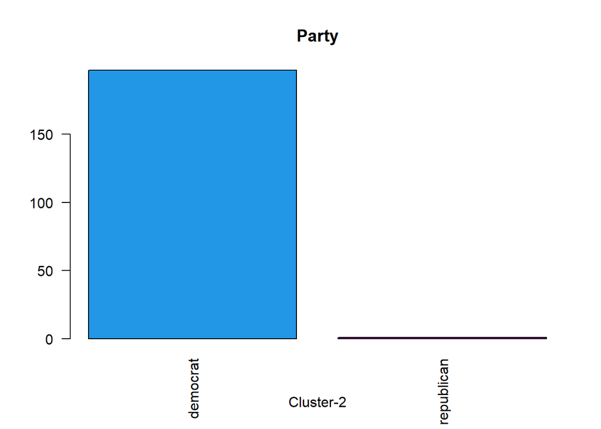

```r
plot(Datos.Cluster2$Party,col=c(4,6),las=2,main="Party",xlab="Cluster-2")
```

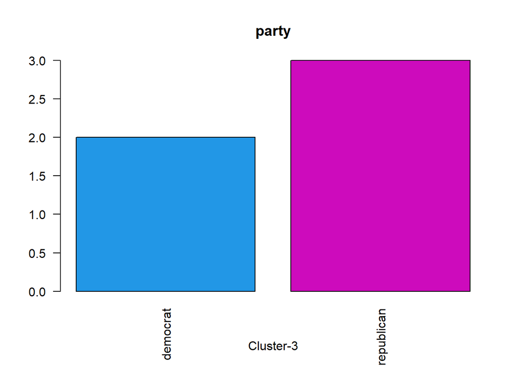

```r
plot(Datos.Cluster3$Party,col=c(4,6),las=2,main="party",xlab="Cluster-3")
```

# EJERCICIO 3

## Realice un analisis similar al del ejercicio anterior con la tabla de datos CompraBicicletas.csv

```r
setwd("~/ALEJANDRO/1er Ciclo 2023/Mineria de Datos/Tarea 4/DatosTarea")
Datos <- read.csv("CompraBicicletas.csv",header=TRUE, sep=";", dec=".")
variables.cualitativas <- sapply(Datos, is.character)
Datos[variables.cualitativas] <- as.data.frame(lapply(Datos[variables.cualitativas], factor))
D<-daisy(as.data.frame(Datos), metric = "euclidean")
jer<-hclust(D, method = "complete")
grupo<-cutree(jer, k = 3)
NDatos<-cbind((Datos),grupo)
dim(NDatos)
```

```
## [1] 1000   14
```

```r
cluster<-NDatos$grupo
sel.cluster1<-match(cluster,c(1),0)
Datos.Cluster1<-NDatos[sel.cluster1>0,]
dim(Datos.Cluster1)
```

```
## [1] 518  14
```

```r
sel.cluster2<-match(cluster,c(2),0)
Datos.Cluster2<-NDatos[sel.cluster2>0,]
dim(Datos.Cluster2)
```

```
## [1] 123  14
```

```r
sel.cluster3<-match(cluster,c(3),0)
Datos.Cluster3<-NDatos[sel.cluster3>0,]
dim(Datos.Cluster3)
```

```
## [1] 359  14
```

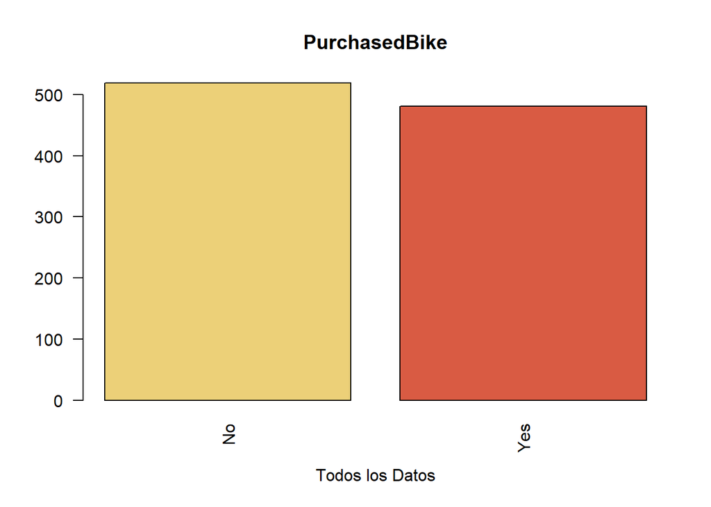

```r
color <- c("#ECD078","#D95B43","#C02942","#542437","#53777A")
plot(Datos$PurchasedBike,col=color,las=2,main="PurchasedBike",xlab="Todos los Datos")
```

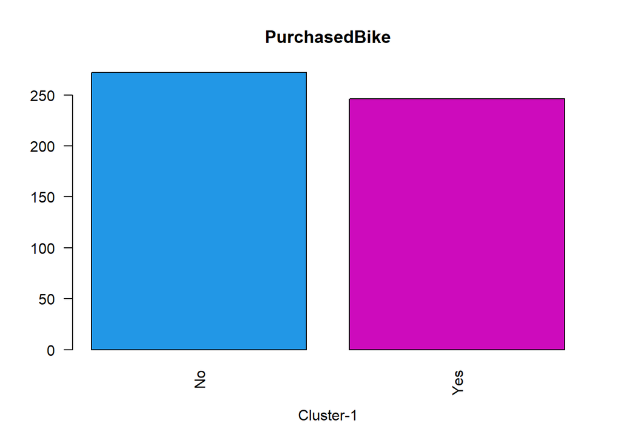

```r
plot(Datos.Cluster1$PurchasedBike,col=c(4,6,7,8,9),las=2,main="PurchasedBike",xlab="Cluster-1")
```

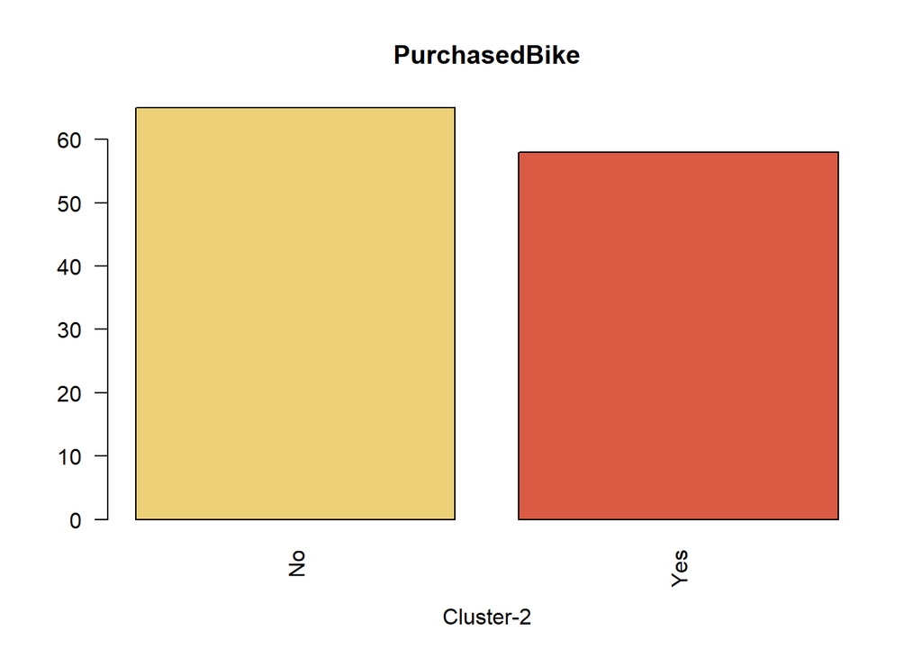

```r
plot(Datos.Cluster2$PurchasedBike,col=color,las=2,main="PurchasedBike",xlab="Cluster-2")
```

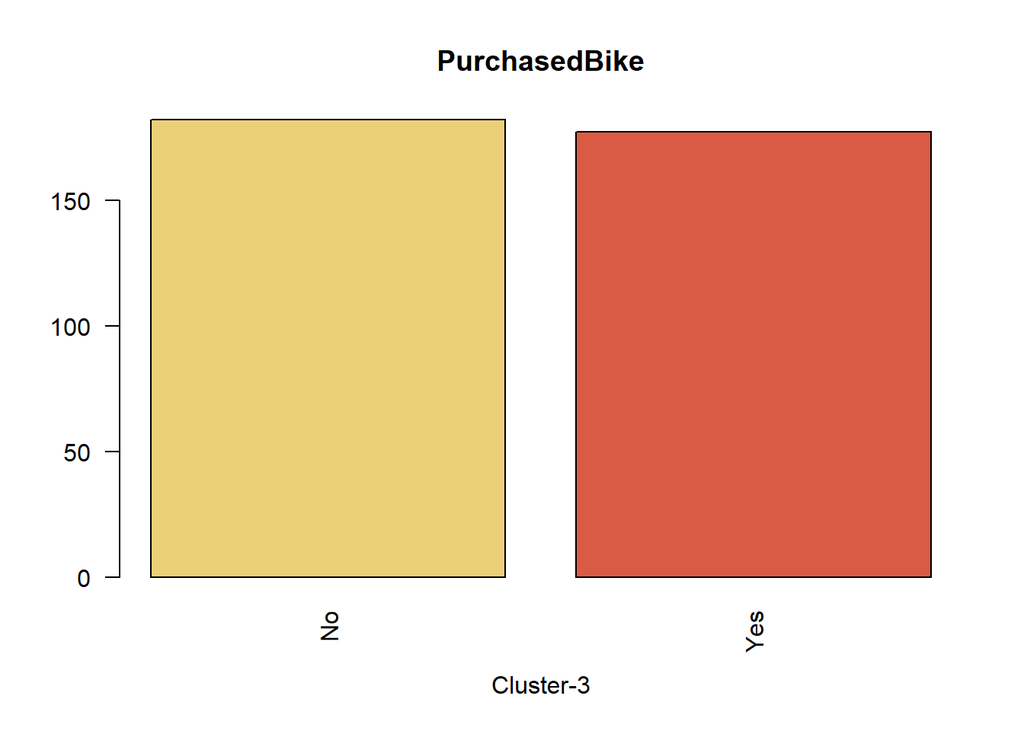

```r
plot(Datos.Cluster3$PurchasedBike,col=color,las=2,main="PurchasedBike",xlab="Cluster-3")
```

# 4. (10 puntos) Dada la siguiente matriz de disimilitudes entre cuatro individuos A1, A2, A3 y A4, construya “a mano” una Jerarquıa Binaria usando la agregacion del Salto Maximo y del Promedio, dibuje el dendograma en ambos casos:

```r
matriz<- matrix(c(0,5,2,3,5,0,1,7,7,1,0,6,3,7,6,0), nrow = 4,dimnames = list(c("A1", "A2", "A3","A4"), c("A1", "A2", "A3","A4")))
matriz<-as.dist(matriz)
matriz
```

```
##    A1 A2 A3
## A2  5
## A3  2  1
## A4  3  7  6
```

#### Para aplicar el salto maximo Podemos ver que el primer valor mayor es 7, corresponde a la posicion (A4,A2), por tanto estos dos van a ser los primeros ejes. Los separamos en 2, en el dendongrama se coloca esta union partiendo desde el valor 7, ya que es el valor maximo, luego la union entre el A1 y A4 se encontraria en el valor de 3, mientras que la union de A2 y A3 se encontraria en el valor 1, como se aprecia en la matriz.

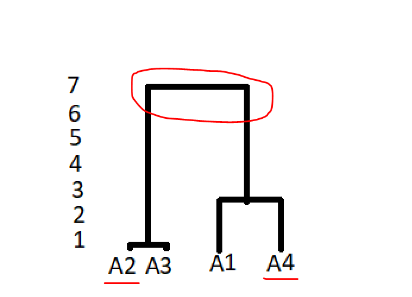

Salto Maximo!

#### Salto Promedio: Promedaimos el valor de cada fila con cada columna, es decir todas contra todas, y luego hacemos algo muy parecido al ejemplo anterior, extraemos los mayores, en este caso el promedio mayor va a ser el que queda en la posicion (A4,A2), desde ahi se parte, y ya que los promedios seran mas grandes dependiendo de los numeros con los que se calculen, el dendongrama va a quedar bastante parecido al del salto maximo.

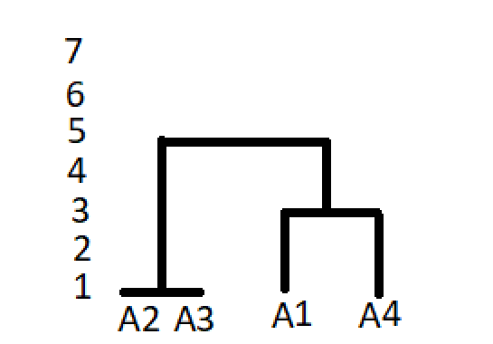

Salto Promedio!

### Comprobacion:

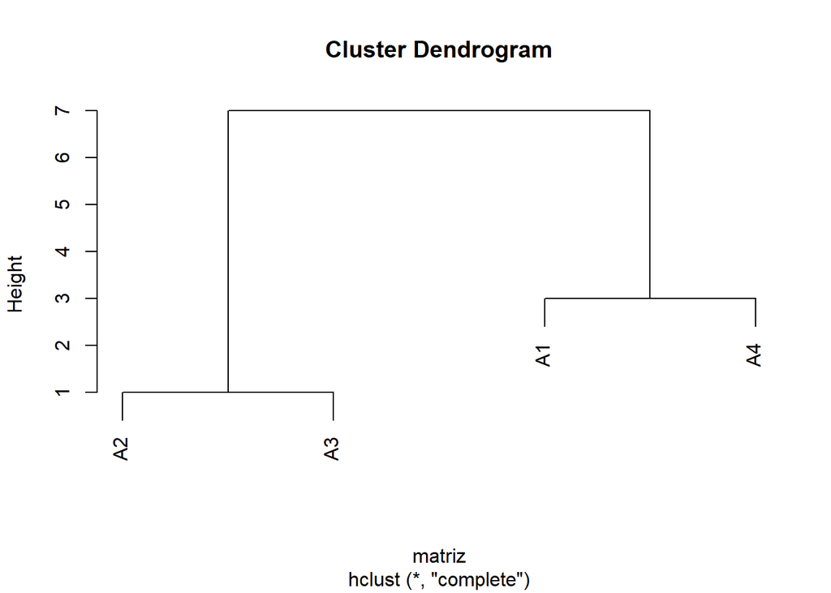

```r
mod<-hclust(matriz,method = "complete")
plot(mod)
```

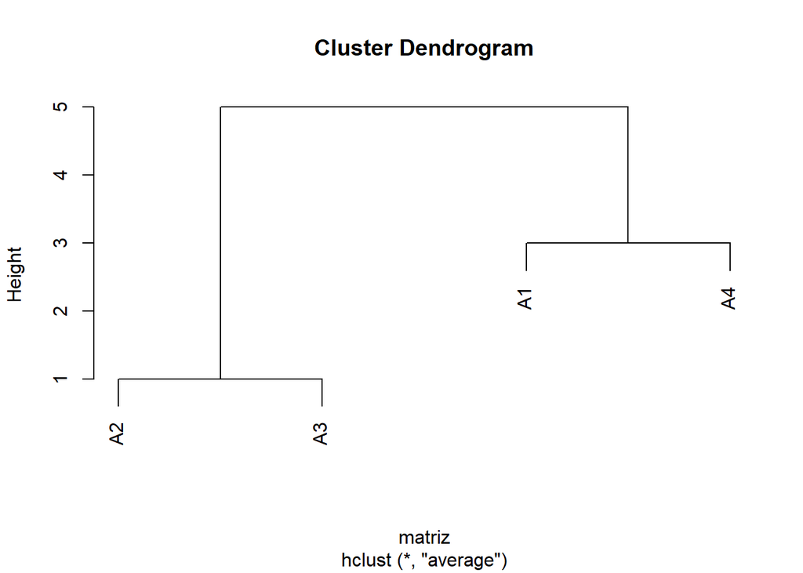

```r
mod<-hclust(matriz,method = "average")
plot(mod)
```